# [다시 고용 한파…취업자 수 39만명 감소](http://www.hani.co.kr/arti/economy/economy_general/966039.html#csidxf7b526547ac9cc69347db4622efdb58)

> 코로나19 재확산 영향으로 넉 달 동안 이어지던 고용 회복세가 꺾였다. 특히 2030 세대가 고용 충격의 직격탄을 맞아 일자리를 대량으로 잃었다.  
> 통계청 관계자는 “코로나 재확산 여파가 고용시장에 처음으로 반영된 것”이라며 “당초 취업자 감소폭은 5월부터 4개월 연속으로 축소됐으나 재확산 영향에 지난달 다시 늘었다”고 설명했다.

코로나의 재확산으로 인해 회복되고 있던 고용률에 다시 적신호가 켜졌다는 기사가 많이 나오고 있다.

기사에서 공통적으로 나오는 '5월부터 4개월 연속 회복되었다.', '9월에 다시 늘었다', '2030 세대가 직격탄을 맞았다'의 내용은 모두 '취업자 수'를 기준으로 말하고 있다.

'취업자수'가 늘었다고 고용상황이 나아지고 있다는 것을 설명할 수 없다. 왜냐하면 실업자도 같이 늘었을 수 있기 때문이다.

고용상황을 대표할 수 있는 것은 무엇일까?

바로 고용률이다. 고용률은 취업자수를 생산가능인구로 나눈 것이기 때문에 고용상황을 대표할 수 있다.

고용률을 기준으로 코로나 발생 이후, 재확산 이후 우리나라 고용상황에 대해 정확히 알아보자.

## 시기별로 고용률이 어떻게 변했는지 알아보자.

|  | 15이상인구 | 경제활동인구 | 비경제활동인구 | 경제활동참가율 | 실업률 | 고용률 | 생산가능인구고용률 |
| --- | --- | --- | --- | --- | --- | --- | --- |
| 2019-10 | 44601 | 28373 | 16228 | 63.6 | 3 | 61.7 | 67.3 |
| 2019-11 | 44625 | 28380 | 16245 | 63.6 | 3.1 | 61.7 | 67.4 |
| 2019-12 | 44661 | 28095 | 16566 | 62.9 | 3.4 | 60.8 | 67.1 |
| 2020-01 | 44665 | 27952 | 16713 | 62.6 | 4.1 | 60 | 66.7 |
| 2020-02 | 44698 | 27991 | 16708 | 62.6 | 4.1 | 60 | 66.3 |
| 2020-03 | 44712 | 27789 | 16923 | 62.2 | 4.2 | 59.5 | 65.4 |
| 2020-04 | 44725 | 27734 | 16991 | 62 | 4.2 | 59.4 | 65.1 |
| 2020-05 | 44756 | 28209 | 16548 | 63 | 4.5 | 60.2 | 65.8 |
| 2020-06 | 44775 | 28283 | 16492 | 63.2 | 4.3 | 60.4 | 65.9 |
| 2020-07 | 44795 | 28244 | 16551 | 63.1 | 4 | 60.5 | 66 |
| 2020-08 | 44813 | 27949 | 16864 | 62.4 | 3.1 | 60.4 | 65.9 |
| 2020-09 | 44829 | 28012 | 16817 | 62.5 | 3.6 | 60.3 | 65.7 |
| 2020-10 | 44852 | 28116 | 16736 | 62.7 | 3.7 | 60.4 | 65.9 |

- **15세이상인구** : 만 15세 이상 인구 = 생산 가능인구.
- **경제활동인구** : 만 15세 이상의 생산가능 연령인구 중에서 구직활동이 가능한 취업자 및 실업자.
  - 일할 능력이 있어 취업한 자와 취업할 의사가 있으면서 취업이 가능한 인구
- **비경제활동인구** : 만 15세가 넘은 인구 가운데 취업자도 실업자도 아닌 사람.
  - 일할 수 있는 능력이 있으나 일할 의사가 없거나, 전혀 일할 능력이 없어 노동공급에 기여하지 못하는 사람.
- **경제활동참가율** : 생산가능인구 중 노동공급에 기여한 사람의 비율.
  - 전인구에 대한 경제활동인구의 비를 **조참가율**이라 한다.
  - 15세 이상 인구에 대한 경제활동인구의 비를 **순참가율**이라 한다.
  - 국제 노동기구 통계연감에서는 **조참가율**을 사용하고 있다.
- **실업률** : 경제활동인구에서 실업자가 차지하는 비율. **[실업자 % 경제활동인구] * 100**
- **고용률** : 15세 이상 생산가능인구 중 취업자가 차지하는 비율.

2019년 10월 ~ 2020년 10월 까지의 데이터를 이용하여 분석을 진행하였다.

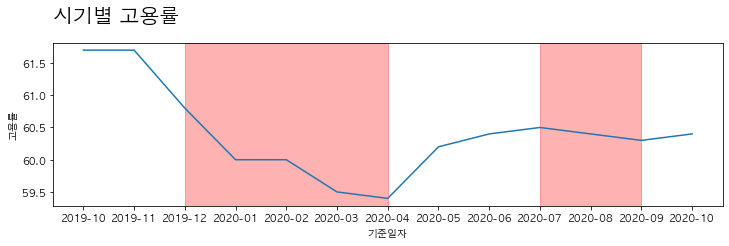

(빨간색으로 색칠한 부분을 주의해주세요.)  
코로나19가 우리 귀에 들리기 시작한 2019년 12월부터 고용률은 낮아지기 시작하였고,  
2020년 4월 고용률 59.4%로 최저고용률을 기록하는 것을 확인할 수 있었다.

4월 이후 점차 회복하는 모습을 보였으나, 8월 코로나의 재확산으로 인해 다시 한번 고용률의 감소를 보였다.  
기사의 내용과 동일하였다.

## 코로나 재확산 이후 어느 연령대가 가장 많이 영향을 받았는지 알아보자.

[interactive chart not shown]

20대의 고용률이 2019년 10월 59%에서 2020년 10월 55.9%로 약 3% 하락하였다.

코로나가 가장 심했던 2020년 3월은 고용률 54.5%로 최고점인 2019년 11월에 비교하여 4.6%나 하락하였다.

3월 이후 조금씩 고용률이 조금씩 회복되다가 재확산 시기인 8월 이후, 고용률이 약 1% 하락하였다.

[interactive chart not shown]

30~50대의 경우 공통적으로 1~4월(코로나 확산시기_주황색부분)까지 고용률이 감소하였고 4월 이후 점차 고용률 회복을 보이고 있다.

두 번째 코로나 확산시기인 8월에는 조금 다른 양상을 보였다.

40~50대인 경우 두번째 확산에는 고용률에 큰 변화가 없었다. 심지어 50대인 경우 8월에 고용률이 소폭 상승하였다.

하지만 30대인 경우 코로나 재확산 때 고용률이 1%나 감소하였다(보라색 동그라미).

코로나 재확산이 20~30대 고용률에 큰 영향을 줬지만 40~50대 고용률에는 별다른 영향이 없었다.

## 결론

취업자 수를 기준으로 고용상황 악화를 말하고 있는 기사내용을 '고용률'을 기준으로 분석하여 검증해보았다.  
그 결과 코로나 확산시기인 1월 ~ 4월, 8월에 고용률이 감소하였다는 것을 확인하였으며 재확산 시기인 8월인 경우 20~30대가 코로나에 큰 영향을 받은 것도 확인할 수 있었다.  
기사의 내용과 동일한 결과를 얻을 수 있었다. 의외다.